# Stats 250: Lab 5 - Solutions

Instructional Team

Week of March 13th

### Instructions

Complete the lab exercises and Dive Deeper questions below. Lab exercises will be graded out of 2 points each and the Dive Deeper questions will be graded out of 3 points each - all of them will be graded for *correctness*. Upon completion, follow the submission instructions at the bottom of this document. We strongly encourage you to work on this assignment with a partner.

### Background

We collected the typing speeds for a random sample of 41 Stats 250 students. These students completed a medium-difficulty one-minute typing test. The number of typed words, with and without errors, was recorded. The `typing` data set contains the following variables:

- `typingSpeed`: the number of words typed in one minute (with errors) (measured in words per minute or wpm)
- `accuracy`: percentage of words typed correctly
- `netSpeed`: the number of words correctly typed in one minute (without errors) (measured in words per minute or wpm)

If you’re interested in your own typing abilities, you can take the one-minute test [here](https://www.typingtest.com/). Select “Medium Text”.

Use the following code chunk to read in the data set.

```r
typing <- read.csv("typingSpeeds.csv")
```

You can preview the data below.

```r
head(typing)
```

```
##   typingSpeed accuracy netSpeed
## 1          48     0.95       46
## 2          60     0.92       55
## 3          46     0.91       42
## 4          58     0.92       53
## 5          58     0.91       53
## 6          41     0.92       38
```

### Lab Exercises

After reading the background above, complete the following lab exercises. Remember, these exercises are worth 2 points each and are graded for correctness.

> **1.** Exercises 1 - 5 will focus on estimating the average typing speed of all Stats 250 students. Use the `qqnorm()` and `qqline()` functions to create a QQ plot for the sample of typing speeds (`typingSpeed`). Is it reasonable to assume that this sample of typing speeds was drawn from a normally distributed population? Briefly explain your answer.

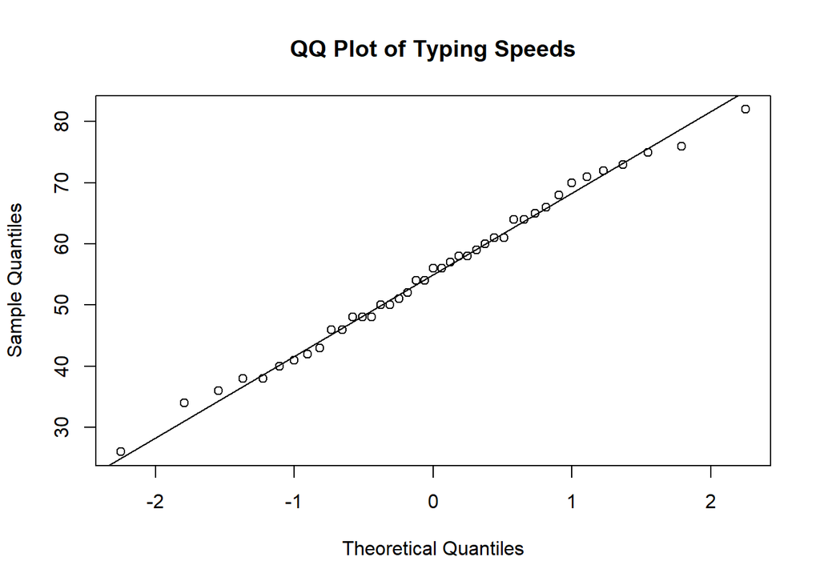

```r
qqnorm(typing$typingSpeed, main = "QQ Plot of Typing Speeds")
qqline(typing$typingSpeed)
```

*Answer:* Yes, it is reasonable to assume that this sample of typing speeds was drawn from a normally distributed population because the points follow along and around the line. (Or because there are no major deviations or obvious patterns.)

> **2.** Provide the symbol and value of the point estimate for the population mean typing speed of Stats 250 students. Note: you will need to use R.

```r
mean(typing$typingSpeed)
```

```
## [1] 55.04878
```

*Answer:* xbar = 55.04878 (words per minute)

> **3.** Calculate the standard *error* for the sampling distribution of the sample mean – s.e.(x_bar). Note: you will need to use R to compute the standard *deviation*. Reference the formula sheet if you forgot how to calculate the standard error!

```r
sd(typing$typingSpeed) / sqrt(41)
```

```
## [1] 2.020309
```

*Answer:* 2.020309 (students can also calculate the standard deviation using R (12.93629) and then use a calculator to get the standard error)

> **4.** Use R to find the t* multiplier for a 90% confidence interval that estimates the population mean typing speed of Stats 250 students. Remember, this multiplier depends on sample size.

```r
qt(p = 0.05, df = 40, lower.tail = FALSE)
```

```
## [1] 1.683851
```

> **5.** Use the `t.test()` function and the `typingSpeed` variable to create the 90% confidence interval for the population mean typing speed of Stats 250 students. Interpret the confidence interval within context.

```r
t.test(typing$typingSpeed, conf.level = 0.90)
```

```
##
##  One Sample t-test
##
## data:  typing$typingSpeed
## t = 27.248, df = 40, p-value < 2.2e-16
## alternative hypothesis: true mean is not equal to 0
## 90 percent confidence interval:
##  51.64688 58.45068
## sample estimates:
## mean of x
##  55.04878
```

*Answer:* We are 90% confident that the population mean typing speed of Stats 250 students is between 51.65 words per minute and 58.45 words per minute.

> **Optional:** Confirm that the values you calculated in Exercises 2 - 4 are correct by using them to calulate the 90% confidence interval “from scratch”. This interval should match the interval you found in Exercise 5.

```r
55.04878 - 1.683851*2.020309
```

```
## [1] 51.64688
```

```r
55.04878 + 1.683851*2.020309
```

```
## [1] 58.45068
```

> **6.** Exercises 6 - 7 will focus on running a hypothesis test for the average *net* typing speed of all Stats 250 students. Use the `qqnorm()` and `qqline()` functions to create a QQ plot for the sample of net typing speeds (`netSpeed`). Is it reasonable to assume that this sample of net typing speeds was drawn from a normally distributed population? Briefly explain your answer.

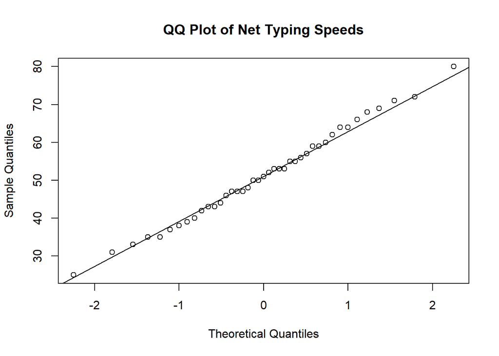

```r
qqnorm(typing$netSpeed, main = "QQ Plot of Net Typing Speeds")
qqline(typing$netSpeed)
```

*Answer:* Yes, it is reasonable to assume that this sample of net typing speeds was drawn from a normally distributed population because the points follow along and around the line. (Or because there are no major deviations or obvious patterns.)

> **7.** The website labels a “fluent” typer as someone who has a *net* typing speed of 45 words per minute. We would like to test if the population mean net typing speed of all Stats 250 students is above this value. Use the `t.test()` function and `netSpeed` variable to run this hypothesis test. Based on the output, evaluate the p-value and provide a conclusion in the context of the problem.

```r
t.test(typing$netSpeed,
       mu = 45,
       alternative = "greater")
```

```
##
##  One Sample t-test
##
## data:  typing$netSpeed
## t = 3.1923, df = 40, p-value = 0.001374
## alternative hypothesis: true mean is greater than 45
## 95 percent confidence interval:
##  47.92736      Inf
## sample estimates:
## mean of x
##  51.19512
```

*Evaluation:* With a p-value of 0.001374, there is very strong evidence against the null hypothesis and in support of the alternative hypothesis.

*Conclusion:* Based on the data, we have very strong evidence to suggest that the population mean net typing speed is greater than 45 words per minute for Stats 250 students.

### Dive Deeper Questions

After completing the lab exercises above, complete the following Dive Deeper questions. Remember, these questions are worth 3 points each and are graded for correctness.

> **1.** The following interpretation of the p-value (from Exercise 7) is incomplete. Finish the statement within the context of the hypothesis test. “The probability of observing a t-test statistic of 3.1923 or greater is 0.001374…”

*Answer:* …assuming the population mean net typing speed of Stats 250 students is 45 words per minute. (We are looking for a reference to “the null hypothesis is true” with some sort of context worked in.)

> **2.** If we had analyzed the typing accuracy (`accuracy`), we would have observed the QQ Plot below. Based on this QQ Plot, we *cannot* conclude that the sample follows a normal model. We have a large enough sample size, however, to utilize the Central Limit Theorem. When we rely on the CLT, what is approximately normal with a sufficiently large sample size? Be specific.

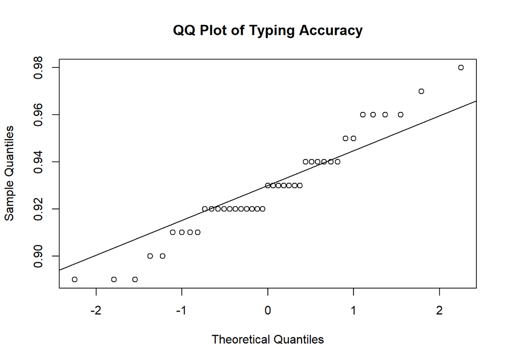

```r
qqnorm(typing$accuracy, main = "QQ Plot of Typing Accuracy")
qqline(typing$accuracy)
```

**Answer:** The sampling distribution of the sample mean (or the sampling distribution of xbar or the distribution of all possible sample means).

### Submission Instructions

Once you have finished, follow the instructions below to submit your work.

1. At the top of the document, update the `author` field. Do not change anything else at the top of the document.
2. Click the Knit button to create an HTML file of your work.
3. In the Files pane (bottom right window), check the box next to `lab05assignment.html`.
4. In the Files pane, click on the gear icon (More) and select “Export…”
5. Do not change the file name (`lab05assignment.html`). Click Download and save the file to your computer.
6. On the Stats 250 Canvas site, navigate to the Lab 5 assignment.
7. Upload your saved `lab05assignment.html` file.
8. Click “Submit Assignment”. Congratulations, you are done with Lab 5!